# Homework 2

### Instructions

1. All assignments are individual!
2. This assignment should be uploaded as two files: “rmd” and “html” (after knit) before the next Tutorial
3. There are questions for two different datasets in this assignment, if you want to pass it, you must complete all of them.
4. Questions about the assignment should be asked using the Assignments forums.
5. All of the instructions of this assignment should be included in the final .html file.

Use **ggplot2** and **dplyr** for data analysis and visualization. Clearly organize your assignment into sections and include appropriate text and code chunks.

# Dataset 1: Admissions (60%)

You are provided with the dataset **`admissions.csv`**, containing data about Master’s program applicants, their test scores, and acceptance status.

```r
library(DescTools)
library(tidyverse)
```

```r
library(ggplot2)
```

## Part 1: Informative Analysi

```r
admission <- read.csv("admission.csv")
head(admission,5)
```

```
##   Serial.No. GRE.Score TOEFL.Score University.Rating SOP CGPA Research
## 1          1       337         118                 4 4.5 9.65        1
## 2          2       324         107                 4 4.0 8.87        1
## 3          3       316         104                 3 3.0 8.00        1
## 4          4       322         110                 3 3.5 8.67        1
## 5          5       314         103                 2 2.0 8.21        0
##   Admission
## 1         1
## 2         1
## 3         1
## 4         1
## 5         0
```

```r
summary(admission)
```

```
##    Serial.No.      GRE.Score      TOEFL.Score    University.Rating
##  Min.   :  1.0   Min.   :290.0   Min.   : 92.0   Min.   :1.000
##  1st Qu.:100.8   1st Qu.:308.2   1st Qu.:103.0   1st Qu.:2.000
##  Median :200.5   Median :317.0   Median :107.0   Median :3.000
##  Mean   :200.5   Mean   :316.8   Mean   :107.4   Mean   :3.087
##  3rd Qu.:300.2   3rd Qu.:325.0   3rd Qu.:112.0   3rd Qu.:4.000
##  Max.   :400.0   Max.   :340.0   Max.   :120.0   Max.   :5.000
##                  NA's   :6
##       SOP           CGPA          Research        Admission
##  Min.   :1.0   Min.   :6.800   Min.   :0.0000   Min.   :0.0000
##  1st Qu.:2.5   1st Qu.:8.180   1st Qu.:0.0000   1st Qu.:0.0000
##  Median :3.5   Median :8.610   Median :1.0000   Median :1.0000
##  Mean   :3.4   Mean   :8.603   Mean   :0.5499   Mean   :0.5875
##  3rd Qu.:4.0   3rd Qu.:9.068   3rd Qu.:1.0000   3rd Qu.:1.0000
##  Max.   :5.0   Max.   :9.920   Max.   :1.0000   Max.   :1.0000
##                NA's   :6       NA's   :9
```

```r
str(admission)
```

```
## 'data.frame':    400 obs. of  8 variables:
##  $ Serial.No.       : int  1 2 3 4 5 6 7 8 9 10 ...
##  $ GRE.Score        : int  337 324 316 322 314 330 321 308 302 323 ...
##  $ TOEFL.Score      : int  118 107 104 110 103 115 109 101 102 108 ...
##  $ University.Rating: int  4 4 3 3 2 5 3 2 1 3 ...
##  $ SOP              : num  4.5 4 3 3.5 2 4.5 3 3 2 3.5 ...
##  $ CGPA             : num  9.65 8.87 8 8.67 8.21 9.34 8.2 7.9 8 8.6 ...
##  $ Research         : int  1 1 1 1 0 1 1 0 NA 0 ...
##  $ Admission        : int  1 1 1 1 0 1 1 0 0 0 ...
```

```r
colSums(is.na(admission))
```

```
##        Serial.No.         GRE.Score       TOEFL.Score University.Rating
##                 0                 6                 0                 0
##               SOP              CGPA          Research         Admission
##                 0                 6                 9                 0
```

```r
sapply(admission[c("GRE.Score", "TOEFL.Score", "SOP", "CGPA")], sd)
```

```
##   GRE.Score TOEFL.Score         SOP        CGPA
##          NA    6.069514    1.006869          NA
```

```r
sapply(admission[c("GRE.Score", "TOEFL.Score", "SOP", "CGPA")], sd, na.rm = TRUE)
```

```
##   GRE.Score TOEFL.Score         SOP        CGPA
##  11.4944700   6.0695138   1.0068686   0.5939467
```

```r
admission %>%
  group_by(Research) %>%
  summarise(mean_cgpa = mean(CGPA, na.rm = TRUE))
```

```
## # A tibble: 3 × 2
##   Research mean_cgpa
##      <int>     <dbl>
## 1        0      8.26
## 2        1      8.89
## 3       NA      8.40
```

```r
admission %>%
  group_by(University.Rating) %>%
  summarise(mean_toefl = mean(TOEFL.Score, na.rm = TRUE))
```

```
## # A tibble: 5 × 2
##   University.Rating mean_toefl
##               <int>      <dbl>
## 1                 1       99.1
## 2                 2      104.
## 3                 3      107.
## 4                 4      112.
## 5                 5      114.
```

```r
admission %>%
  filter(!is.na(Research)) %>%
  count(Research) %>%
  mutate(percentage = round(100 * n / sum(n), 1))
```

```
##   Research   n percentage
## 1        0 176         45
## 2        1 215         55
```

- Provide detailed feature descriptions, including meanings, types, and statistics (mean, median, standard deviation, min, max).
- Discuss clearly the following relationships:
  - Mean CGPA difference by research experience.
  - Mean TOEFL scores by University Ratings.
1. Serial.No. Row number index; serves only as a unique identifier.

Mean: 200.5 | Median: 200.5

Min: 1 | Max: 400

2. GRE.Score Graduate Record Examination score – measures general academic ability. Typical range: 260–340.

Mean: 316.8 | Median: 317.0

Min: 290 | Max: 340

Missing values: 6

3. TOEFL.Score Test of English as a Foreign Language – measures English proficiency. Range: 0–120.

Mean: 107.4 | Median: 107.0

Min: 92 | Max: 120

Missing values: 0

4. University.Rating A rating of the university where the applicant studied (scale: 1–5).

Mean: 3.09 | Median: 3

Min: 1 | Max: 5

Missing values: 0

5. SOP Strength of the Statement of Purpose – subjective score given to applicant’s personal essay.

Mean: 3.40 | Median: 3.5

Min: 1.0 | Max: 5.0

Missing values: 0

6. CGPA Cumulative Grade Point Average from undergraduate studies (scale: 0–10).

Mean: 8.60 | Median: 8.61

Min: 6.80 | Max: 9.92

Missing values: 6

7. Research Indicates whether the applicant has research experience. Categorical: 1 = Yes, 0 = No

Mean: 0.55 → ~55% have research experience

Missing values: 9

8. Admission Indicates whether the applicant was admitted. Binary: 1 = Admitted, 0 = Not admitted

Mean: 0.59 → ~59% were admitted

Min: 0 | Max: 1

Missing values: 0

As University Rating increases, the average TOEFL score also rises. For example, students admitted to universities rated 5 had a mean TOEFL score of 113.67, compared to just 99.08 in universities rated 1. This suggests that higher-ranked universities tend to accept students with stronger English proficiency.

## Part 2: Data Processing

```r
admission_clean <- admission %>%
  mutate(
    GRE.Score = replace_na(GRE.Score, median(GRE.Score, na.rm = TRUE)),
    Research  = replace_na(Research, Mode(Research, na.rm = TRUE)),
    CGPA      = replace_na(CGPA, mean(CGPA, na.rm = TRUE))
  )
```

- Clearly handle missing values with justifications:
  - GRE Score: Replace missing with median. Why is median preferred here?

We replaced missing values with the median. This is because GRE scores might include some extreme values, and the median is less affected by outliers than the mean.

- Research: Replace missing with mode. Explain your reasoning clearly. For this binary (0/1) variable, we used the mode, meaning the most frequent value in the column. Since there are only two possible values, it makes sense to fill in the missing ones with the value that appears more often.
- CGPA: Replace missing with mean. Justify your choice of mean here.

Missing values in CGPA were replaced with the mean. In this case, the mean and median are nearly identical, and the standard deviation is quite low, which suggests that the values are concentrated around the center and follow an approximately normal distribution. This makes the mean a reliable value for imputation.

## Part 3: Data Visualization

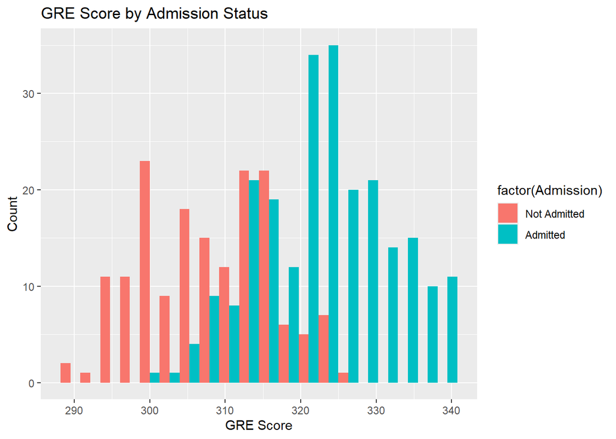

```r
ggplot(admission_clean, aes(x = GRE.Score, fill = factor(Admission))) +
  geom_histogram(position = "dodge", bins = 20) +
  labs(title = "GRE Score by Admission Status", x = "GRE Score", y = "Count") +
  scale_fill_discrete(labels = c("Not Admitted", "Admitted"))
```

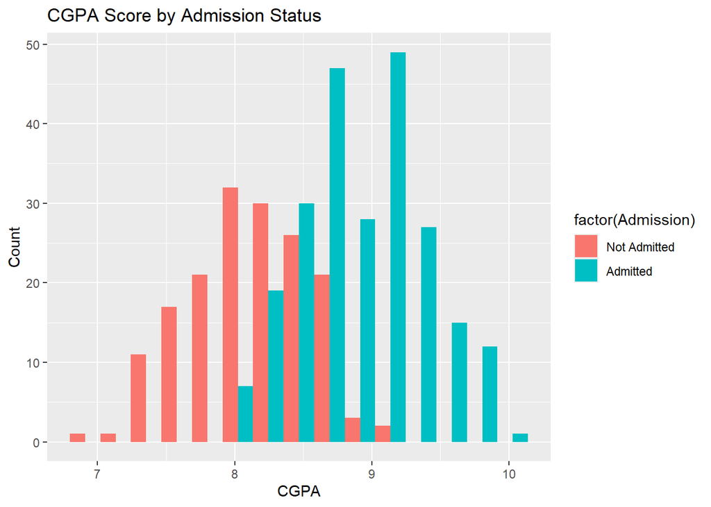

```r
ggplot(admission_clean, aes(x = CGPA , fill = factor(Admission))) +
  geom_histogram(position = "dodge", bins = 15) +
  labs(title = "CGPA Score by Admission Status", x = "CGPA", y = "Count") +
  scale_fill_discrete(labels = c("Not Admitted", "Admitted"))
```

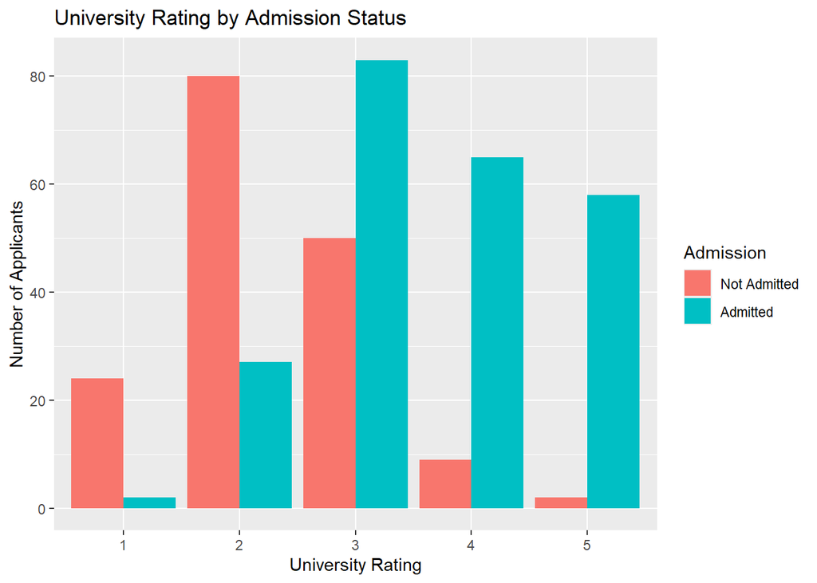

```r
ggplot(admission_clean, aes(x = factor(University.Rating), fill = factor(Admission))) +
  geom_bar(position = "dodge") +
  labs(
    title = "University Rating by Admission Status",
    x = "University Rating",
    y = "Number of Applicants",
    fill = "Admission"
  ) +
  scale_fill_discrete(labels = c("Not Admitted", "Admitted"))
```

Create the following detailed plots using **ggplot2**:

1. Histogram of GRE Scores by Admission status.
2. Histogram of CGPA by Admission status.
3. Bar plot: Applicants count per University Rating by Admission (interpret clearly).

# Dataset 2: Titanic (40%)

You are provided with the dataset **`titanic.csv`**, containing passenger details and survival information.

```r
titanic <- read.csv("titanic.csv")
head(titanic,5)
```

```
##   PassengerId Survived Pclass                                  Name    Sex Age
## 1         181        0      3          Sage, Miss. Constance Gladys female  NA
## 2         182        0      2                      Pernot, Mr. Rene   male  NA
## 3         183        0      3 Asplund, Master. Clarence Gustaf Hugo   male   9
## 4         184        1      2             Becker, Master. Richard F   male   1
## 5         185        1      3   Kink-Heilmann, Miss. Luise Gretchen female   4
##   SibSp Parch        Ticket    Fare Cabin Embarked
## 1     8     2      CA. 2343 69.5500              S
## 2     0     0 SC/PARIS 2131 15.0500              C
## 3     4     2        347077 31.3875              S
## 4     2     1        230136 39.0000    F4        S
## 5     0     2        315153 22.0250              S
```

```r
summary(titanic)
```

```
##   PassengerId       Survived        Pclass          Name
##  Min.   :181.0   Min.   :0.00   Min.   :1.000   Length:419
##  1st Qu.:285.5   1st Qu.:0.00   1st Qu.:1.000   Class :character
##  Median :390.0   Median :0.00   Median :3.000   Mode  :character
##  Mean   :390.0   Mean   :0.42   Mean   :2.258
##  3rd Qu.:494.5   3rd Qu.:1.00   3rd Qu.:3.000
##  Max.   :599.0   Max.   :1.00   Max.   :3.000
##
##      Sex                 Age            SibSp            Parch
##  Length:419         Min.   : 0.75   Min.   :0.0000   Min.   :0.0000
##  Class :character   1st Qu.:22.00   1st Qu.:0.0000   1st Qu.:0.0000
##  Mode  :character   Median :29.00   Median :0.0000   Median :0.0000
##                     Mean   :30.45   Mean   :0.4869   Mean   :0.3532
##                     3rd Qu.:39.00   3rd Qu.:1.0000   3rd Qu.:0.0000
##                     Max.   :71.00   Max.   :8.0000   Max.   :4.0000
##                     NA's   :91
##     Ticket               Fare           Cabin             Embarked
##  Length:419         Min.   :  0.00   Length:419         Length:419
##  Class :character   1st Qu.:  7.91   Class :character   Class :character
##  Mode  :character   Median : 14.50   Mode  :character   Mode  :character
##                     Mean   : 33.68
##                     3rd Qu.: 30.50
##                     Max.   :512.33
##
```

```r
str(titanic)
```

```
## 'data.frame':    419 obs. of  12 variables:
##  $ PassengerId: int  181 182 183 184 185 186 187 188 189 190 ...
##  $ Survived   : int  0 0 0 1 1 0 1 1 0 0 ...
##  $ Pclass     : int  3 2 3 2 3 1 3 1 3 3 ...
##  $ Name       : chr  "Sage, Miss. Constance Gladys" "Pernot, Mr. Rene" "Asplund, Master. Clarence Gustaf Hugo" "Becker, Master. Richard F" ...
##  $ Sex        : chr  "female" "male" "male" "male" ...
##  $ Age        : num  NA NA 9 1 4 NA NA 45 40 36 ...
##  $ SibSp      : int  8 0 4 2 0 0 1 0 1 0 ...
##  $ Parch      : int  2 0 2 1 2 0 0 0 1 0 ...
##  $ Ticket     : chr  "CA. 2343" "SC/PARIS 2131" "347077" "230136" ...
##  $ Fare       : num  69.5 15.1 31.4 39 22 ...
##  $ Cabin      : chr  "" "" "" "F4" ...
##  $ Embarked   : chr  "S" "C" "S" "S" ...
```

```r
colSums(is.na(titanic))
```

```
## PassengerId    Survived      Pclass        Name         Sex         Age
##           0           0           0           0           0          91
##       SibSp       Parch      Ticket        Fare       Cabin    Embarked
##           0           0           0           0           0           0
```

```r
sum(titanic$Cabin == "", na.rm = TRUE)
```

```
## [1] 318
```

```r
sum(titanic$Embarked == "", na.rm = TRUE)
```

```
## [1] 10
```

## Part 1: Informative Analysis

- Clearly describe features, their meanings, and statistics (mean, median, standard deviation, min, max).
1. PassengerId Unique identifier for each passenger.

Mean: 390.0 | Median: 390.0 | Min: 181 | Max: 599

2. Survived Survival status: 0 = Did not survive, 1 = Survived.

Mean: 0.42 → around 42% survived

Min: 0 | Max: 1

3. Pclass Ticket class: 1 = 1st class, 2 = 2nd class, 3 = 3rd class.

Mean: 2.26 | Median: 3 | Mode: 3

Min: 1 | Max: 3

4. Name Passenger’s full name (not used for numerical analysis).

Text (Character) – includes title (Mr., Miss, etc.)

5. Sex Gender: male or female.

Categorical – useful for analyzing survival differences between genders.

6. Age Passenger’s age in years.

Mean: 30.45 | Median: 29 | Min: 0.75 | Max: 71

Missing values: 91 (≈22% of the data)

7. SibSp Number of siblings or spouses aboard the Titanic.

Mean: 0.49 | Median: 0 | Min: 0 | Max: 8

8. Parch Number of parents or children aboard.

Mean: 0.35 | Median: 0 | Min: 0 | Max: 4

9. Ticket Ticket number (alphanumeric).

Character – often inconsistent format, rarely useful without preprocessing.

10. Fare Ticket fare paid (in British pounds).

Mean: 33.68 | Median: 14.5 | Min: 0 | Max: 512.33

11. Cabin Cabin number – often missing or partial.

Mostly missing – not used unless heavily cleaned.

12. Embarked Port of embarkation:

C = Cherbourg, Q = Queenstown, S = Southampton Categorical – can be useful in grouping passengers.

```r
titanic %>%
  group_by(Pclass) %>%
  summarise(
    count = sum(!is.na(Age)),
    mean_age = mean(Age, na.rm = TRUE),
    median_age = median(Age, na.rm = TRUE),
    sd_age = sd(Age, na.rm = TRUE)
  )
```

```
## # A tibble: 3 × 5
##   Pclass count mean_age median_age sd_age
##    <int> <int>    <dbl>      <dbl>  <dbl>
## 1      1    94     37.8       36.5   15.1
## 2      2    85     30.2       30     13.3
## 3      3   149     26.0       25     12.3
```

```r
titanic %>%
  group_by(Sex, Survived) %>%
  summarise(count = n()) %>%
  arrange(Sex,desc(Survived))
```

[output not shown]

```
## # A tibble: 4 × 3
## # Groups:   Sex [2]
##   Sex    Survived count
##   <chr>     <int> <int>
## 1 female        1   123
## 2 female        0    38
## 3 male          1    53
## 4 male          0   205
```

```r
titanic %>%
  group_by(Pclass, Survived) %>%
  summarise(count = n()) %>%
  arrange(Pclass, desc(Survived))
```

```
## # A tibble: 6 × 3
## # Groups:   Pclass [3]
##   Pclass Survived count
##    <int>    <int> <int>
## 1      1        1    72
## 2      1        0    37
## 3      2        1    48
## 4      2        0    45
## 5      3        1    56
## 6      3        0   161
```

```r
titanic %>%
  group_by(Sex, Pclass, Survived) %>%
  summarise(count = n()) %>%
  arrange(Sex, Pclass, desc(Survived))
```

```
## # A tibble: 12 × 4
## # Groups:   Sex, Pclass [6]
##    Sex    Pclass Survived count
##    <chr>   <int>    <int> <int>
##  1 female      1        1    52
##  2 female      1        0     2
##  3 female      2        1    38
##  4 female      2        0     3
##  5 female      3        1    33
##  6 female      3        0    33
##  7 male        1        1    20
##  8 male        1        0    35
##  9 male        2        1    10
## 10 male        2        0    42
## 11 male        3        1    23
## 12 male        3        0   128
```

```r
titanic %>%
  group_by(Pclass, Sex) %>%
  summarise(
    mean_fare = mean(Fare, na.rm = TRUE),
    median_fare = median(Fare, na.rm = TRUE),
    min_fare = min(Fare, na.rm = TRUE),
    count = n()
  )
```

```
## # A tibble: 6 × 6
## # Groups:   Pclass [3]
##   Pclass Sex    mean_fare median_fare min_fare count
##    <int> <chr>      <dbl>       <dbl>    <dbl> <int>
## 1      1 female     111.        86.5     27.7     54
## 2      1 male        66.2       35.5      0       55
## 3      2 female      19.7       19.5     10.5     41
## 4      2 male        17.7       13.2      0       52
## 5      3 female      14.9       10.5      7.23    66
## 6      3 male        11.7        7.90     0      151
```

```r
  titanic %>%
  group_by(SibSp, Survived) %>%
  summarise(count = n()) %>%
  arrange(SibSp, Survived, desc(Survived))
```

```
## # A tibble: 12 × 3
## # Groups:   SibSp [7]
##    SibSp Survived count
##    <int>    <int> <int>
##  1     0        0   181
##  2     0        1   108
##  3     1        0    42
##  4     1        1    57
##  5     2        0     6
##  6     2        1     8
##  7     3        0     4
##  8     3        1     1
##  9     4        0     5
## 10     4        1     2
## 11     5        0     2
## 12     8        0     3
```

- Provide four detailed insights examining interesting or less obvious relationships:
  - Does age distribution differ significantly by class?

  Passengers in 1st class tend to be older, with higher median and average age,3rd class includes more young passengers and children,These findings indicate that age distribution does vary significantly by class, likely reflecting the socioeconomic composition of the passengers.
  - Analyze survival rates based on gender and passenger class.

In every class, women paid more on average than men. For example, in 1st class, women paid an average of 110.81, while men paid 66.25.

In 2nd and 3rd class, the difference is smaller, but still noticeable: 2nd class: women 19.73 vs. men 17.75 3rd class: women 14.94 vs. men 11.69

Also, the minimum fare for men is 0 in all classes, suggesting that some male passengers may have boarded for free (perhaps as crew, servants, or under special circumstances). This pulls the average down for men, especially in 1st class. These patterns suggest that fare price is correlated with both gender and class, and that women—especially in 1st class—tended to pay more, possibly because they had better cabins or were part of wealthier families.

- Provide one additional insightful relationship of your own and discuss why it’s interesting or important. One additional insightful relationship we found is between the number of siblings or spouses on board (SibSp) and the chance of survival. Passengers with no family aboard (SibSp = 0) had a survival rate of about 37% (108 out of 289), which is lower than those with exactly one sibling or spouse, who had a survival rate of 57% (57 out of 99). This suggests that having one close companion might have helped people survive—possibly due to emotional support or better coordination during the evacuation. However, as the number of family members increased beyond two, the survival rate dropped again, possibly because larger families had a harder time staying together or making it to lifeboats. This non-linear pattern makes the relationship interesting and potentially important for understanding group behavior in emergencies.

## Part 2: Data Processing

```r
titanic_clean <- titanic %>%
  select(-Cabin) %>%
  mutate(
    Age = replace_na(Age, median(Age, na.rm = TRUE)),
    Embarked = ifelse(Embarked == "", Mode(Embarked), Embarked)
  )
glimpse(titanic_clean)
```

```
## Rows: 419
## Columns: 11
## $ PassengerId <int> 181, 182, 183, 184, 185, 186, 187, 188, 189, 190, 191, 192…
## $ Survived    <int> 0, 0, 0, 1, 1, 0, 1, 1, 0, 0, 1, 0, 1, 1, 1, 1, 0, 0, 1, 0…
## $ Pclass      <int> 3, 2, 3, 2, 3, 1, 3, 1, 3, 3, 2, 2, 3, 2, 1, 1, 3, 3, 3, 2…
## $ Name        <chr> "Sage, Miss. Constance Gladys", "Pernot, Mr. Rene", "Asplu…
## $ Sex         <chr> "female", "male", "male", "male", "female", "male", "femal…
## $ Age         <dbl> 29.0, 29.0, 9.0, 1.0, 4.0, 29.0, 29.0, 45.0, 40.0, 36.0, 3…
## $ SibSp       <int> 8, 0, 4, 2, 0, 0, 1, 0, 1, 0, 0, 0, 1, 1, 0, 0, 0, 0, 0, 0…
## $ Parch       <int> 2, 0, 2, 1, 2, 0, 0, 0, 1, 0, 0, 0, 0, 1, 0, 0, 0, 1, 0, 0…
## $ Ticket      <chr> "CA. 2343", "SC/PARIS 2131", "347077", "230136", "315153",…
## $ Fare        <dbl> 69.5500, 15.0500, 31.3875, 39.0000, 22.0250, 50.0000, 15.5…
## $ Embarked    <chr> "S", "C", "S", "S", "S", "S", "Q", "S", "Q", "S", "S", "S"…
```

- Clearly and explicitly justify how you handle missing values in each feature. Your explanation should reflect an understanding of data quality and analytical considerations.

Age is a continuous variable with potential outliers (e.g., infants and elderly). The median is a robust central measure that is not affected by extreme values, making it a reliable choice for imputation.

Embarked is a categorical variable. Using the most common value preserves the distribution and avoids introducing bias when only 10 rows missing.

The Cabin feature is missing in most observations and has inconsistent formatting.(318 rows missing) Imputing such a sparse and unstructured field would add noise rather than meaningful information.

## Part 3: Data Visualization

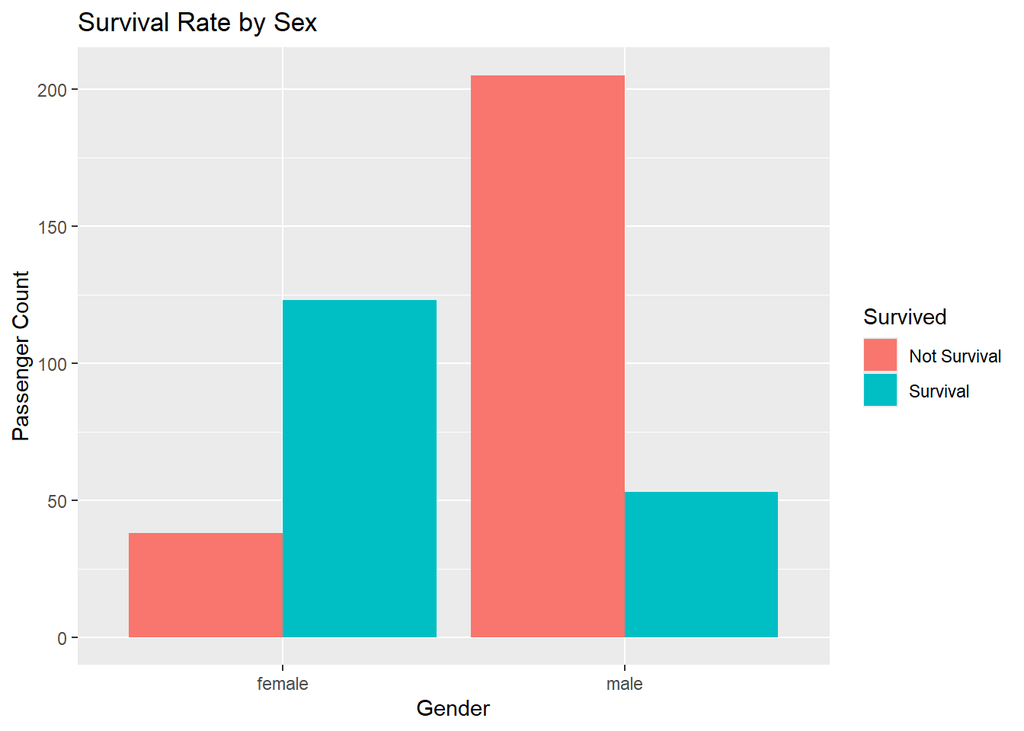

```r
ggplot(titanic_clean, aes(x = Sex, fill = factor(Survived))) +
  geom_bar(position = "dodge") +
  labs(
    title = "Survival Rate by Sex",
    x = "Gender",
    y = "Passenger Count",
    fill = "Survived"
  ) +
  scale_fill_discrete(labels = c("Not Survival", "Survival"))
```

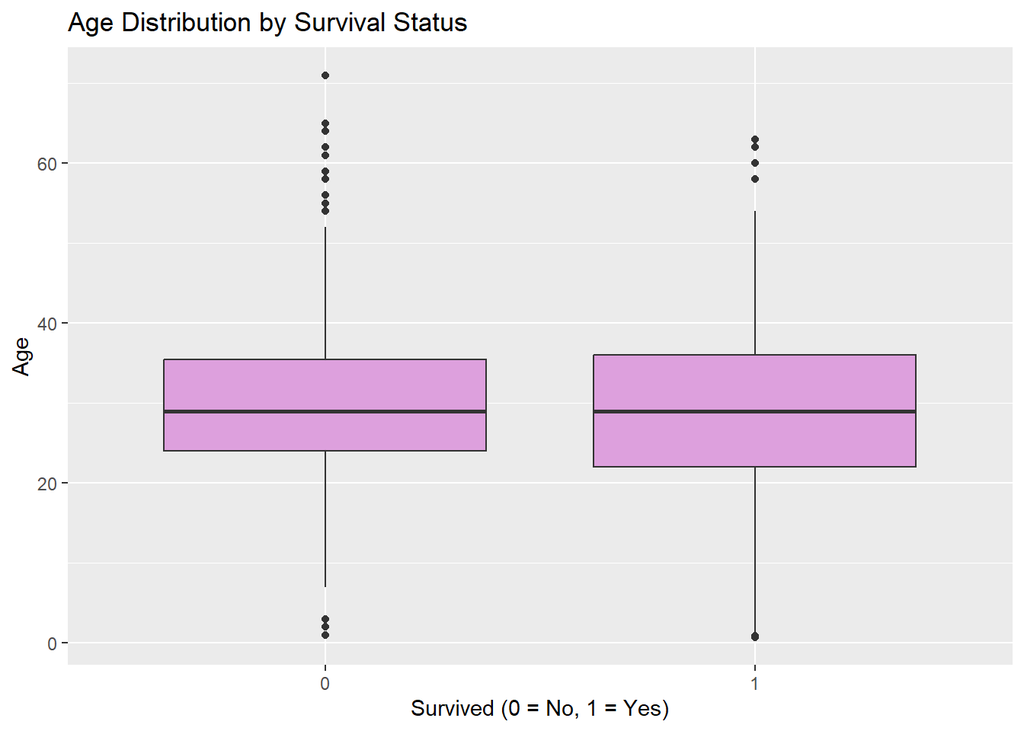

```r
ggplot(titanic_clean,aes(x = factor(Survived), y = Age))+
  geom_boxplot(fill = "plum")+
  labs(
    title = "Age Distribution by Survival Status",
    x = "Survived (0 = No, 1 = Yes)",
    y = "Age"
  )
```

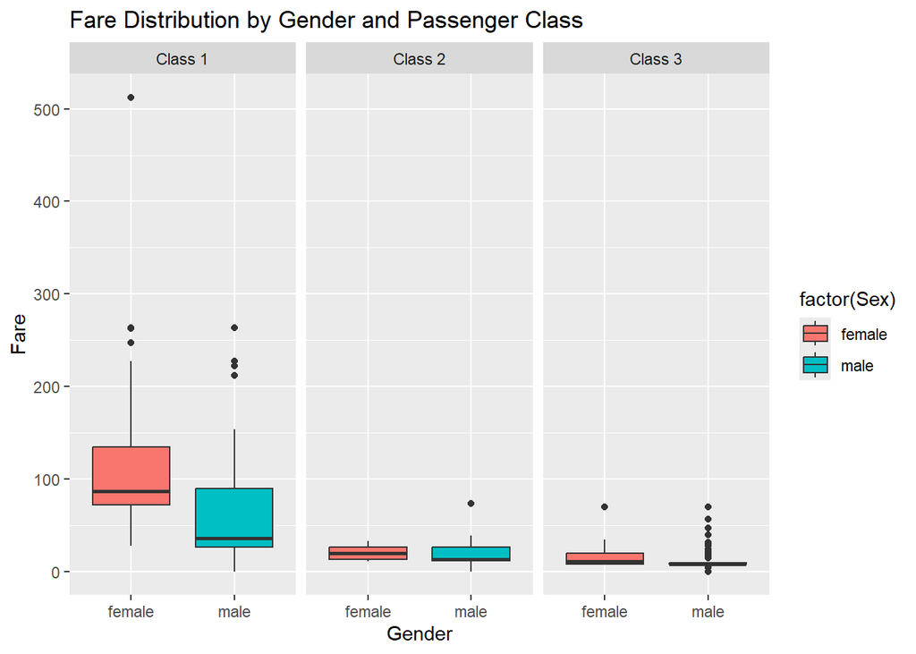

```r
ggplot(titanic_clean, aes(x = factor(Sex), y = Fare)) +
  geom_boxplot(aes(fill = factor(Sex))) +
  facet_wrap(~Pclass, labeller = labeller(Pclass = c(
    "1" = "Class 1",
    "2" = "Class 2",
    "3" = "Class 3"
  ))) +
  labs(
    title = "Fare Distribution by Gender and Passenger Class",
    x = "Gender",
    y = "Fare"
  )
```

```r
survival_rates <- titanic_clean %>%
  group_by(Pclass, Sex) %>%
  summarise(
    survived_rate = mean(Survived),
    count = n()
  )
```

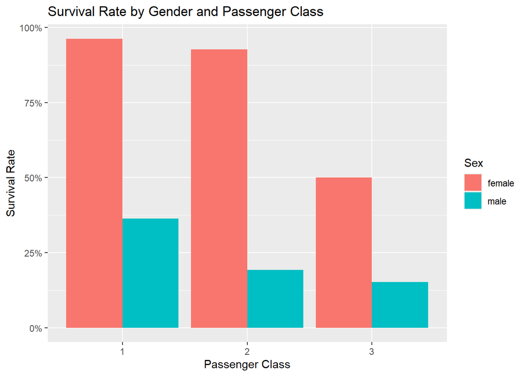

```r
ggplot(survival_rates, aes(x = factor(Pclass), y = survived_rate, fill = Sex)) +
  geom_col(position = "dodge") +
  labs(
    title = "Survival Rate by Gender and Passenger Class",
    x = "Passenger Class",
    y = "Survival Rate"
  ) +
  scale_y_continuous(labels = scales::percent_format(accuracy = 1))
```

Select and create **four informative plots** using **ggplot2**:

- Clearly justify why each plot was chosen and discuss the insights each provides about the Titanic dataset. One plot should specifically focus on an interaction between three or more variables. Explain the complexity and your reasoning for this choice.

Plot 1: Survival Count by Gender – Justification and Insights This bar chart was chosen to visually compare survival outcomes between males and females. A grouped bar plot (using position = “dodge”) is ideal for this, as it clearly separates survival counts by gender, allowing for an immediate side-by-side comparison.

Bar plots are particularly effective when comparing categorical variables, such as Sex and Survived, especially when the goal is to highlight disparities between groups.

Why this visualization is effective: It directly shows the contrast in survival numbers between genders.

It makes it visually obvious that female passengers had a significantly higher survival count than males.

Insight: The plot highlights a major historical and social dynamic — “women and children first” — reflected in the much higher survival count for women compared to men.

Plot 2: Age Distribution by Survival Status – Justification and Insights This boxplot displays the distribution of passenger age for those who survived and those who did not. A boxplot is the ideal visualization in this case because it shows:

The median age for each group

The interquartile range (IQR), revealing variability

Any outliers (e.g., very young or very old passengers)

This type of plot is especially useful when comparing a continuous variable (Age) against a binary outcome (Survived), helping to identify differences in central tendency and spread.

Several elderly passengers who did not survive (ages 60+)

And a few very young children or infants who also didn’t survive. These anomalies may reflect the challenges certain vulnerable groups faced, or limitations in evacuation procedures.

Plot 3: Fare Distribution by Gender and Passenger Class – Justification and Insights This boxplot compares ticket prices between male and female passengers, separated by travel class. Using facet_wrap() allows us to clearly examine whether fare differences between genders exist within each class.

Boxplots are ideal for showing central tendencies (median), variability, and outliers, making it easy to compare the fare distributions.

Insight: In 1st class, female passengers show several extremely high fare outliers, suggesting that some women may have traveled in luxury private cabins or were part of high status groups.

Among male passengers, we observe some zero fare entries, which may indicate special cases such as crew members, employees, or individuals who were not required to pay.

In both 2nd and 3rd class, the fare distributions are generally lower and more compact, with no major gender-based deviations in the middle range.

This visualization provides a nuanced look at how ticket price, gender, and class intersect, offering insight into possible privilege, status, or special arrangements that certain passengers may have had — especially in 1st class.

Plot 4: Survival Rate by Gender and Passenger Class Justification and Insights This grouped bar plot displays the survival rate of Titanic passengers, broken down by both gender and passenger class. Each bar represents the proportion of survivors within a specific subgroup rather than absolute counts.

Using geom_col() with grouped bars is ideal here, as it enables clear comparisons across multiple categories, while fill = Sex adds a visual layer for gender differences.

Why this visualization is effective: It allows us to observe the interaction between two categorical predictors (Sex and Pclass) on the survival outcome.

It highlights relative trends (survival rates) rather than just frequencies, making it easier to interpret the impact of social and structural factors on survival.

Insights: Female passengers in 1st class had the highest survival rate, with nearly all surviving.

Male passengers in 3rd class had the lowest survival rate, with fewer than 20% surviving.

This visualization provides a clear, interpretable summary of a three-variable interaction, making it a strong choice for a complex pattern in the data.